# Noortalunike meetmes osalenud ettevõtete kasv sõltub tegevusalast

Jüri Lillemets

6. detsember 2017

Noortalunike meetme[^1] rakendamist alustati juba 2008. aastal, mil toimus esimene taotlusvoor. Meetme abil on toetatud noori põllumajandustootjaid seega varsti juba 10 aastat. Kuigi MAK 2007-2013 programmiperiood on lõppenud, maksti meetme 1.2 toetusi välja veel 2015. aastal. Võttes arvesse ka asjaolu, et investeeringute mõju ettevõtetele avaldub alles pikema perioodi jooksul, on nüüd sobilik aeg hinnata, kuidas on toetatud noortalunikel[^2] läinud. Järgnevalt kirjeldataksegi, kuidas muutus erinevate tegevusalade ja aastate lõikes noortalunike müügitulu (siin ka käive), mis iseloomustab hästi ettevõtete kasvu.

# Noortalunike müügitulu kasvas teistest tootjatest erinevalt

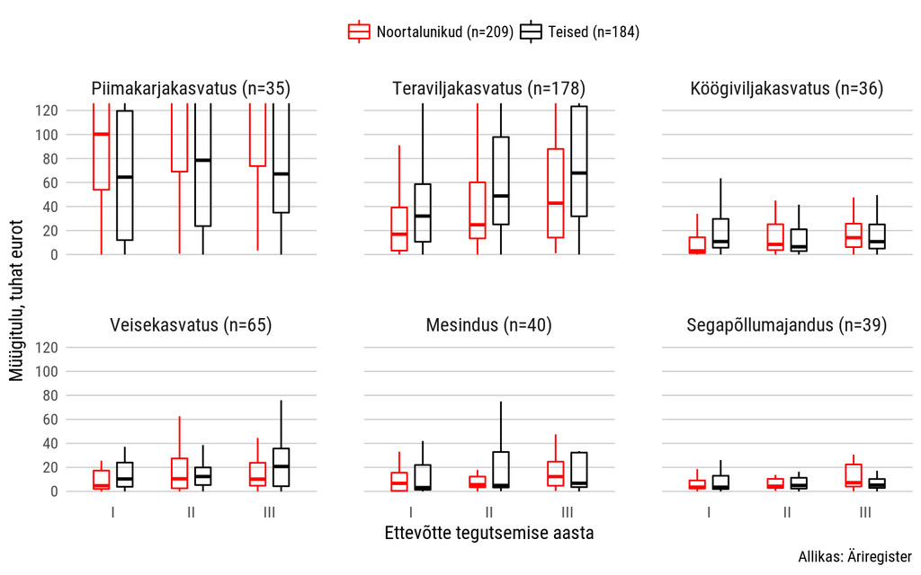

Joonis 1. Müügitulu absoluutne muutus esimesel kolmel tegutsemise aastal.

# Müügitulu kasv oli aeglaseim piimakarjakasvatajatel

Kuigi noortalunike müügitulu kasvas mediaani järgi hinnates kõikidel tegevusaladel, võib joonis 2 alusel öelda, et kasvu kiirus sõltus tegutsemise aastast ja tegevusalast. Kõige kiiremini ja ka stabiilsemalt tõusis käve nootalunikel, kes tegelesid segapõllumajanduse ja teraviljakasvatusega. Teistest tegevusaladest märkimisväärselt aeglasemalt kasvas müügitulu aga piimakarjakasvatuses, kus käibed olid samas ka kõige kõrgemad.

Keskmise noortaluniku müügitulu kasvumustri alusel võib tegevusalad joonise 2 alusel jagada kolmeks. Teraviljakasvatuses ja sellega osalt seotud segapõllumajanduses kasvas müügitulu lineaarselt. Väiksema käibega tegevuste puhul nagu köögiviljakasvatus ja mesindus kasvas müügtulu alles kolmandal aastal. Vastupidi oli (piima)veisekasvatuses, mille puhul kasvas müügitulu küll teisel, aga mitte oluliselt enam kolmandal aastal.

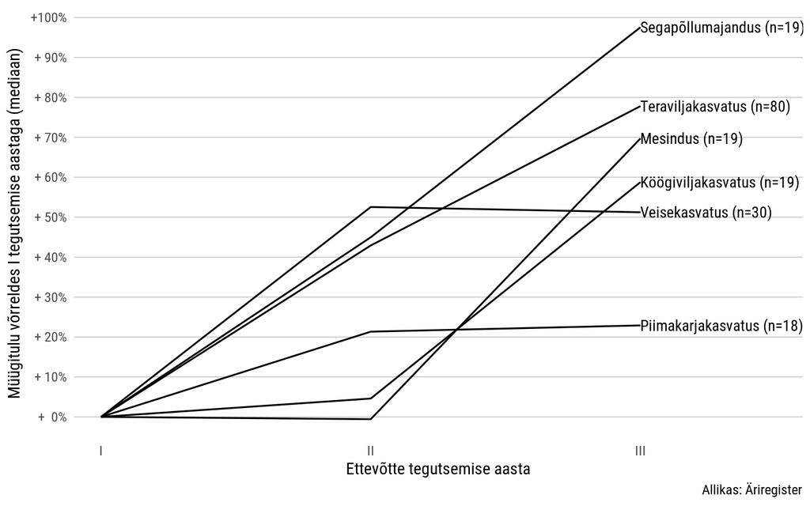

Joonis 2. Noortalunike müügitulu suhteline muutus esimesel kolmel tegutsemise aastal.

# Toetus süvendas erinevusi müügitulus

Teatud kõrvalekalle joonisel 3 ilmneb viiendal aastal, kui madalama käibega noortalunike müügitulu kasvas üsna järsult üle 20 tuhande euro piiri. Seda saab seletada meetme nõudega, mille kohaselt pidi toetuse saamisele järgneva viienda kalendriaasta lõpuks taotleja aastamüügitulu põllumajanduslikust tegevusest moodustama vähemalt 80% saadud toetuse summast. Võib oletada, et selle tähtaja lähenedes on madalama käibega tootjad teinud lisapingutusi, et enda müügitulu vastavale tasemele viia või piisavalt kõrgena näidata.

Mõneti üllatavalt nähtub jooniselt 3, et alustavatena määratletud noortalunike käive oli pigem kõrgem kui noortel, kes senist tegevust jätkasid või vanematelt üle võtsid. Alustajate ja teiste noortalunike käibe erinevus vähenes aga aasta aastalt ja viiendal aastal ei olnud see erinevus enam statistiliselt oluline. Kuigi üldiselt erinevused noortalunike vahel müügitulus pärast toetuse saamist kasvasid, siis erinevused alustavate ja teiste noortalunike müügitulus samal ajal pigem vähenesid.

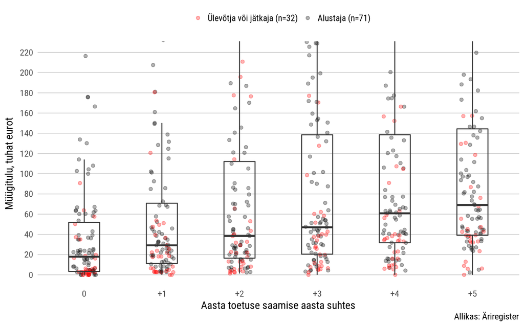

Joonis 3. Noortalunike müügitulu muutus investeeringu tegemise suhtes.

[^1]: Eesti Maaelu Arengukava (MAK) 2007-2013 meede 1.2 “Põllumajandusliku tegevusega alustava noore ettevõtja toetus”. Meetme rakendamine jätkub kehtiva MAK raames sama nimetuse all.
[^2]: Siin ja edaspidi MAK 2007-2013 meetme 1.2 raames toetatud ettevõtted.
[^3]: Joonistel 1 ja 3 on kujutatud ettevõtjate jaotust karpdiagrammina, millel horisontaaljoon tähistab mediaani ehk keskmist ettevõtet, kastis paikneb keskmine 50% ettevõtjatest ja sellest välja ulatuvad vertikaaljooned katavad ülejäänud (va äärmusliku müügituluga) ettevõtted.